# R包变化可真快

jmzeng1314

11/3/2017

看起来单细胞转录组测序领域宣传的最广的就是这个 `scater` 包了，我刻意学了它全部两百多页的教程，也处理好了自己的项目数据，都准备发教程了。

才过去一个星期，我想用之前的代码准备处理一下新的数据。

发现它所有的代码均不可用了，底层逻辑就被改变了。就是 2017年 11 月之前的代码里面的函数，对象很多都被取消了。

## 文档

最新的文档如下：

| [HTML](http://bioconductor.org/packages/release/bioc/vignettes/scater/inst/doc/vignette-intro.html) | [R Script](http://bioconductor.org/packages/release/bioc/vignettes/scater/inst/doc/vignette-intro.R) | An introduction to the scater package |
| --- | --- | --- |
| [HTML](http://bioconductor.org/packages/release/bioc/vignettes/scater/inst/doc/vignette-dataviz.html) | [R Script](http://bioconductor.org/packages/release/bioc/vignettes/scater/inst/doc/vignette-dataviz.R) | Data visualisation methods in scater |
| [HTML](http://bioconductor.org/packages/release/bioc/vignettes/scater/inst/doc/vignette-quantimport.html) | [R Script](http://bioconductor.org/packages/release/bioc/vignettes/scater/inst/doc/vignette-quantimport.R) | Expression quantification and import |
| [HTML](http://bioconductor.org/packages/release/bioc/vignettes/scater/inst/doc/vignette-qc.html) | [R Script](http://bioconductor.org/packages/release/bioc/vignettes/scater/inst/doc/vignette-qc.R) | Quality control with scater |
| [HTML](http://bioconductor.org/packages/release/bioc/vignettes/scater/inst/doc/vignette-transition.html) | [R Script](http://bioconductor.org/packages/release/bioc/vignettes/scater/inst/doc/vignette-transition.R) | Transition from SCESet to SingleCellExperiment |
| [PDF](http://bioconductor.org/packages/release/bioc/manuals/scater/man/scater.pdf) |  |  |

而且其GitHub的教程也更新了：http://hemberg-lab.github.io/scRNA.seq.course/

这里就不重复介绍他们以前的代码了，说多了都是泪啊！！！

## 测试数据+对象

```r
suppressPackageStartupMessages(library(scater))
data("sc_example_counts")
data("sc_example_cell_info")

example_sce <- SingleCellExperiment(
    assays = list(counts = sc_example_counts), colData = sc_example_cell_info)

exprs(example_sce) <- log2(
    calculateCPM(example_sce, use.size.factors = FALSE) + 1)

keep_feature <- rowSums(exprs(example_sce) > 0) > 0
example_sce <- example_sce[keep_feature,]

example_sce <- calculateQCMetrics(example_sce,
                                  feature_controls = list(eg = 1:40))

#scater_gui(example_sce)
```

但是真的非常好用，所有的可视化都集中在了 `scater_gui` 这个函数产生的`shiny`网页里面：

- `plotScater`: a plot method exists for `SingleCellExperiment` objects, which gives an overview of expression across cells.
- `plotQC`: various methods are available for producing QC diagnostic plots.
- `plotPCA`: produce a principal components plot for the cells.
- `plotTSNE`: produce a t-distributed stochastic neighbour embedding (reduced dimension) plot for the cells.
- `plotDiffusionMap`: produce a diffusion map (reduced dimension) plot for the cells.
- `plotMDS`: produce a multi-dimensional scaling plot for the cells.
- `plotReducedDim`: plot a reduced-dimension representation of the cells.
- `plotExpression`: plot expression levels for a defined set of features.
- `plotPlatePosition`: plot cells in their position on a plate, coloured by cell metadata and QC metrics or feature expression level.
- `plotColData`: plot cell metadata and QC metrics.
- `plotRowData`: plot feature metadata and QC metrics.

可以充分的探索自己的数据。

## 可视化大全

前面说到可以用 `shiny`网页来进行各种各样的可视化，其实也可以拆分开来。

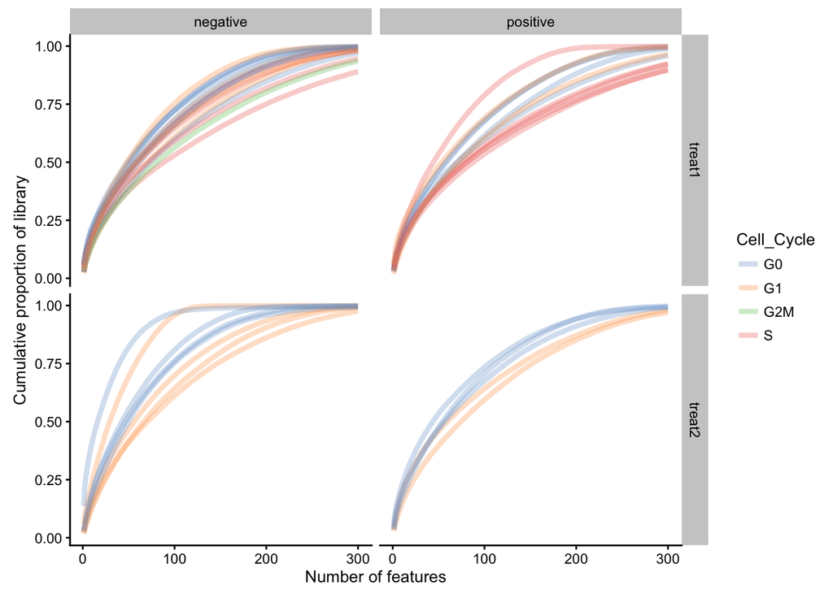

```r
library(ggplot2)
theme_set(theme_bw(12))

## ----plot-sceset-blocking, eval=TRUE---------------------------------------
suppressPackageStartupMessages(library(scater))
data("sc_example_counts")
data("sc_example_cell_info")
example_sce <- SingleCellExperiment(
    assays = list(counts = sc_example_counts), colData = sc_example_cell_info)
exprs(example_sce) <- log2(calculateCPM(example_sce,
                                        use.size.factors = FALSE) + 1)

plotScater(example_sce, block1 = "Mutation_Status", block2 = "Treatment",
     colour_by = "Cell_Cycle", nfeatures = 300, exprs_values = "counts")
```

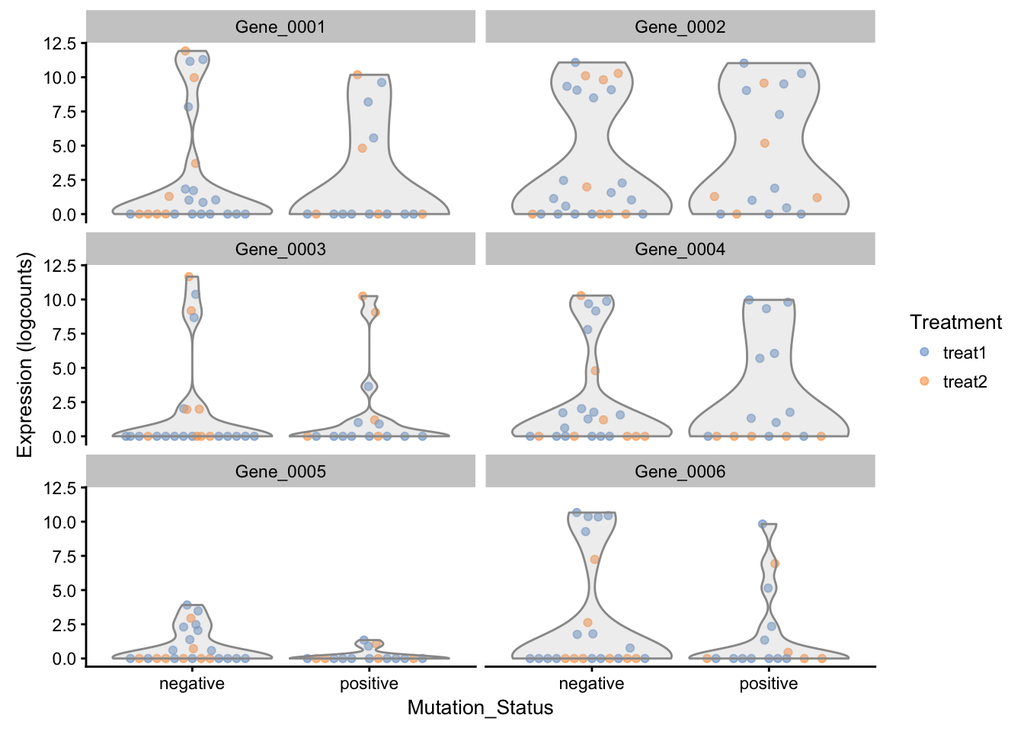

```r
## ----plot-expression, eval=TRUE--------------------------------------------
plotExpression(example_sce, rownames(example_sce)[1:6],
               x = "Mutation_Status", exprs_values = "exprs",
               colour = "Treatment")
```

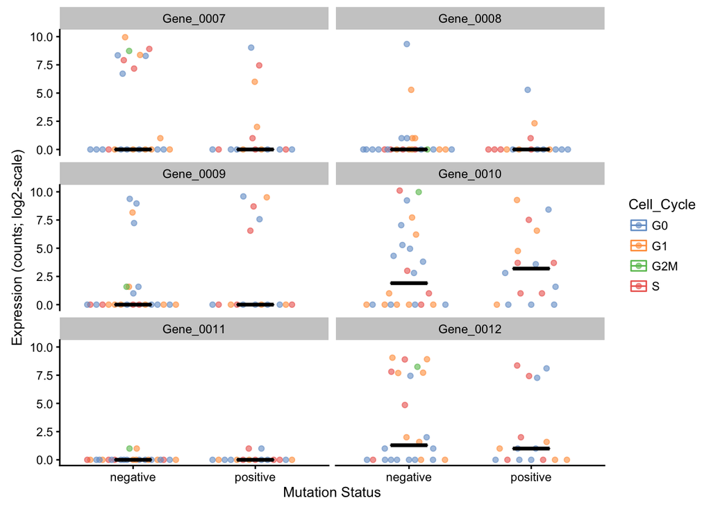

```r
## ----plot-expression-theme-bw, eval=TRUE-----------------------------------
plotExpression(example_sce, rownames(example_sce)[7:12],
               x = "Mutation_Status", exprs_values = "counts",
               colour = "Cell_Cycle",
               show_median = TRUE, show_violin = FALSE,  xlab = "Mutation Status",
               log = TRUE)
```

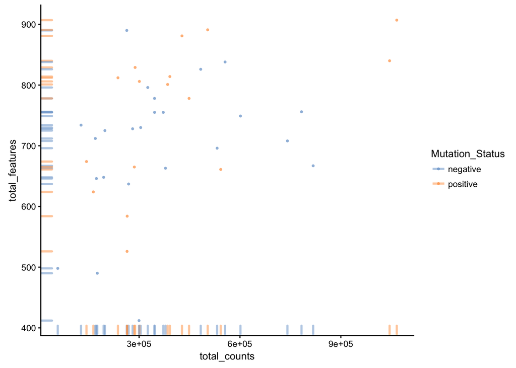

```r
## ----plot-pdata, echo=TRUE, fig.show=TRUE, results='hide', eval=TRUE-------
example_sce <- calculateQCMetrics(example_sce,
                                  feature_controls = list(dummy = 1:40))
plotColData(example_sce, aes(x = total_counts, y = total_features,
                                  colour = Mutation_Status))
```

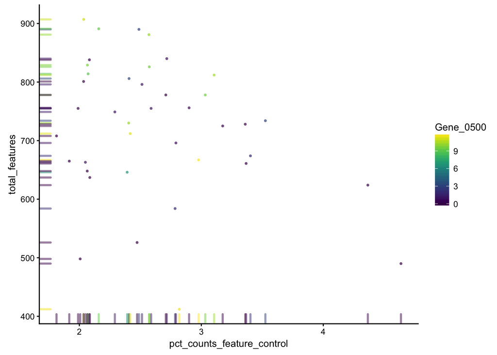

```r
## ----plot-pdatacol-gene-exprs-2, fig.show = TRUE, eval=TRUE----------------
plotColData(example_sce, aes(x = pct_counts_feature_control,
                                  y = total_features, colour = Gene_0500))
```

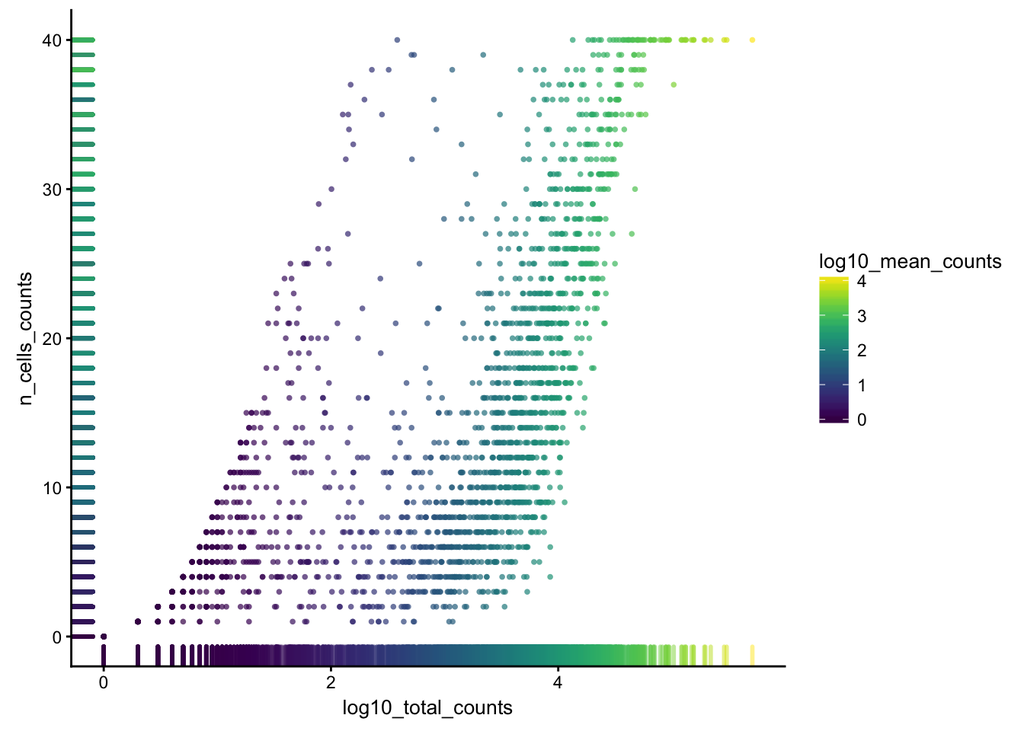

```r
## ----plot-fdata, echo=TRUE, fig.show=TRUE, results='hide', eval=TRUE-------
plotRowData(example_sce, aes(x = log10_total_counts, y = n_cells_counts,
                                  colour = log10_mean_counts))
```

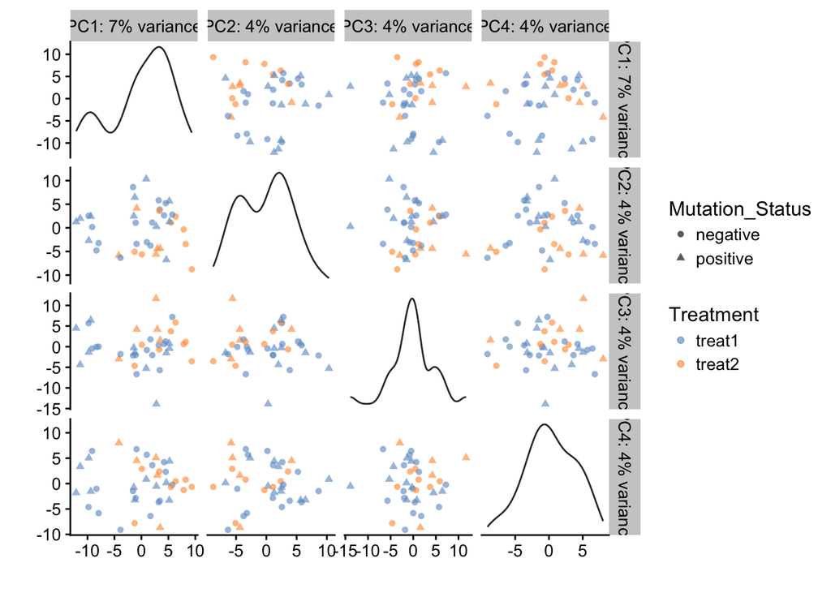

```r
## ----plot-pca-4comp-colby-shapeby-save-pcs, fig.show = FALSE, eval=TRUE----
example_sce <- plotPCA(example_sce, ncomponents = 4,
                          colour_by = "Treatment", shape_by = "Mutation_Status",
                          return_SCE = TRUE, theme_size = 12)
```

```r
reducedDims(example_sce)
```

```
## List of length 1
## names(1): PCA
```

```r
head(reducedDim(example_sce))
```

```
##                  PC1       PC2        PC3        PC4
## Cell_001 -11.3549969  1.987128 -4.3684884  3.3630354
## Cell_002  -1.4129121  2.494169 -0.2695877 -0.7532469
## Cell_003   2.0117100  1.128543 -2.0464581  3.6275892
## Cell_004  -9.8008989  2.562876  5.6841074 -4.6117327
## Cell_005   6.3489281  2.393014  5.8535812  0.4598489
## Cell_006  -0.9004187 -3.396119 -6.6698769  6.7846540
```

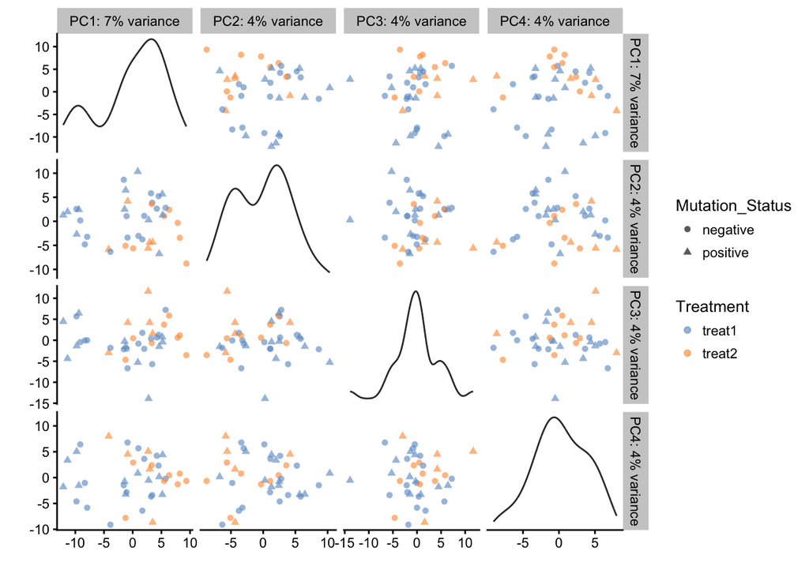

```r
## ----plot-reduceddim-4comp-colby-shapeby, fig.show=FALSE, eval=TRUE--------
plotReducedDim(example_sce, use_dimred = "PCA", ncomponents = 4,
               colour_by = "Treatment", shape_by = "Mutation_Status")
```

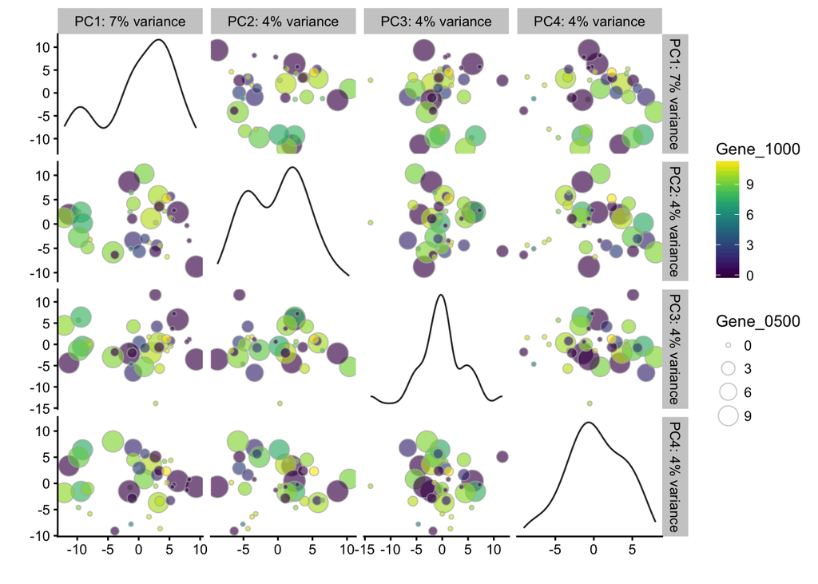

```r
## ----plot-reduceddim-4comp-colby-sizeby-exprs, fig.show = FALSE, eval=TRUE----
plotReducedDim(example_sce, use_dimred = "PCA", ncomponents = 4,
               colour_by = "Gene_1000", size_by = "Gene_0500")
```

```r
## ----plot-pca-default, eval=TRUE-------------------------------------------
plotPCA(example_sce)
```

[output not shown]

```r
## ----plot-pca-cpm, eval=TRUE-----------------------------------------------
plotPCA(example_sce, exprs_values = "cpm")
```

[output not shown]

```r
## ----plot-pca-feature-controls, fig.show = FALSE, eval=TRUE----------------
plotPCA(example_sce, feature_set = fData(example_sce)$is_feature_control)
```

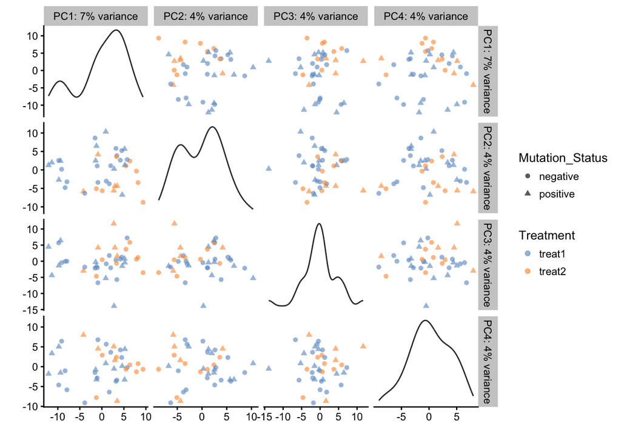

```r
## ----plot-pca-4comp-colby-shapeby, fig.height=5.5, eval=TRUE---------------
plotPCA(example_sce, ncomponents = 4, colour_by = "Treatment",
        shape_by = "Mutation_Status")
```

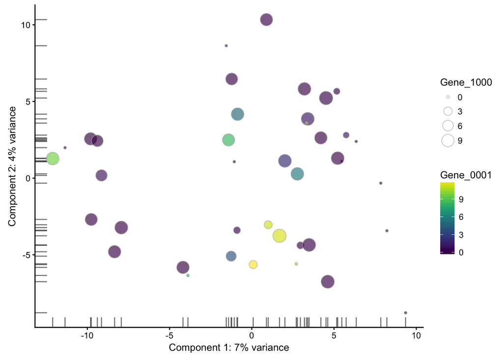

```r
## ----plot-pca-4comp-colby-sizeby-exprs, fig.height=5.5, eval=TRUE----------
plotPCA(example_sce, colour_by = "Gene_0001", size_by = "Gene_1000")
```

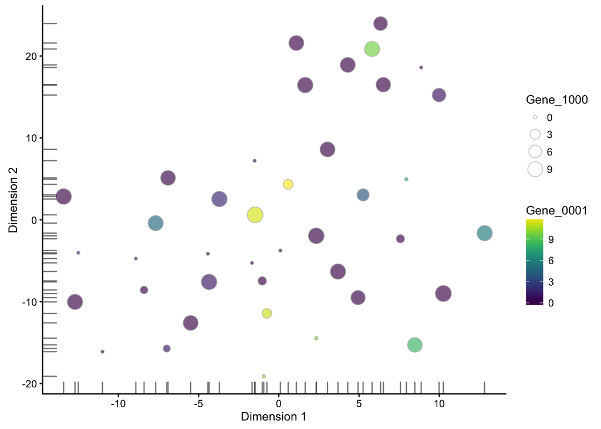

```r
## ----plot-tsne-1comp-colby-sizeby-exprs, fig.height=5.5, eval=TRUE---------
plotTSNE(example_sce, colour_by = "Gene_0001", size_by = "Gene_1000")
```

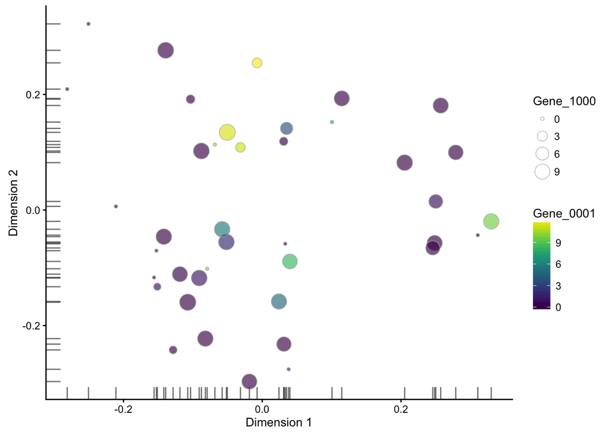

```r
## ----plot-difmap-1comp-colby-sizeby-exprs, fig.height=5.5, eval=TRUE-------
plotDiffusionMap(example_sce, colour_by = "Gene_0001", size_by = "Gene_1000")
```